# BIMS 6000 R Tutorial 2019

## 4. Comments

The final piece of any good script in R are comments. Comments have a ‘#’ at the front of the line, and their purpose is to help you remember why you did things. When you are in the middle of analyzing your data, everything you are doing will seem so clear, but two months later when you’re writing a methods section, you’ll thank past you for writing really descriptive comments, that can help guide you through the code. For example:

```r
### This is a comment, just to remind myself what I was up to. This command will summarize each column. For numeric data, this will output the minimum value, the maxiumum value, and the 1st and 3rd quartiles.
summary(exp_data)
```

```
       ID            Race           CAPRASgroup             ANO7            ASF1B            ASPM           AZGP1            BGN
 Min.   :  1.0   Length:327         Length:327         Min.   : 6.620   Min.   :1.870   Min.   :1.860   Min.   : 9.01   Min.   : 8.97
 1st Qu.: 82.5   Class :character   Class :character   1st Qu.: 9.975   1st Qu.:4.090   1st Qu.:3.725   1st Qu.:13.44   1st Qu.:10.21
 Median :164.0   Mode  :character   Mode  :character   Median :10.720   Median :4.690   Median :4.360   Median :14.08   Median :10.77
 Mean   :164.0                                         Mean   :10.650   Mean   :4.749   Mean   :4.506   Mean   :13.86   Mean   :10.87
 3rd Qu.:245.5                                         3rd Qu.:11.350   3rd Qu.:5.290   3rd Qu.:5.120   3rd Qu.:14.54   3rd Qu.:11.43
 Max.   :327.0                                         Max.   :13.730   Max.   :7.400   Max.   :7.540   Max.   :15.74   Max.   :13.73
     BIRC5           BUB1B          C6orf10         CAMK2N1           CDC20           CDCA3            CDK1           CDKN3
 Min.   :3.520   Min.   :2.260   Min.   :0.000   Min.   : 7.850   Min.   :4.080   Min.   :1.080   Min.   :3.600   Min.   :3.040
 1st Qu.:4.930   1st Qu.:4.270   1st Qu.:3.060   1st Qu.: 9.300   1st Qu.:5.175   1st Qu.:3.320   1st Qu.:4.955   1st Qu.:4.245
 Median :5.530   Median :4.710   Median :3.570   Median : 9.720   Median :5.600   Median :3.790   Median :5.380   Median :4.740
 Mean   :5.552   Mean   :4.751   Mean   :3.653   Mean   : 9.785   Mean   :5.736   Mean   :4.084   Mean   :5.439   Mean   :4.742
 3rd Qu.:6.130   3rd Qu.:5.190   3rd Qu.:4.195   3rd Qu.:10.185   3rd Qu.:6.185   3rd Qu.:4.500   3rd Qu.:5.850   3rd Qu.:5.225
 Max.   :8.260   Max.   :6.670   Max.   :7.330   Max.   :13.560   Max.   :7.790   Max.   :7.610   Max.   :8.030   Max.   :6.840
     CENPF           CENPM           CEP55          COL1A1          DLGAP5           DTL            EPPK1            FAM13C
 Min.   :3.680   Min.   :2.770   Min.   :1.78   Min.   : 8.13   Min.   :0.360   Min.   :0.210   Min.   : 5.930   Min.   : 6.810
 1st Qu.:4.930   1st Qu.:4.440   1st Qu.:3.72   1st Qu.:10.11   1st Qu.:2.435   1st Qu.:2.275   1st Qu.: 7.430   1st Qu.: 9.200
 Median :5.470   Median :4.900   Median :4.31   Median :10.84   Median :2.930   Median :2.710   Median : 7.880   Median : 9.560
 Mean   :5.594   Mean   :4.989   Mean   :4.38   Mean   :10.81   Mean   :2.998   Mean   :2.712   Mean   : 7.927   Mean   : 9.532
 3rd Qu.:6.235   3rd Qu.:5.420   3rd Qu.:5.03   3rd Qu.:11.46   3rd Qu.:3.505   3rd Qu.:3.130   3rd Qu.: 8.380   3rd Qu.: 9.970
 Max.   :8.960   Max.   :7.470   Max.   :7.01   Max.   :13.79   Max.   :5.470   Max.   :4.910   Max.   :10.820   Max.   :11.050
      FLNC           FOXM1            GSN            GSTM2            IQGAP3         KIAA0101         KIF11           KIF20A
 Min.   : 7.58   Min.   :2.710   Min.   :10.30   Min.   : 6.830   Min.   :2.270   Min.   :1.240   Min.   :2.100   Min.   :0.470
 1st Qu.: 9.62   1st Qu.:4.520   1st Qu.:11.68   1st Qu.: 9.190   1st Qu.:3.975   1st Qu.:2.970   1st Qu.:4.510   1st Qu.:3.130
 Median :10.16   Median :4.970   Median :12.07   Median : 9.880   Median :4.570   Median :3.520   Median :4.910   Median :3.730
 Mean   :10.19   Mean   :5.058   Mean   :12.06   Mean   : 9.733   Mean   :4.706   Mean   :3.503   Mean   :4.977   Mean   :3.958
 3rd Qu.:10.82   3rd Qu.:5.515   3rd Qu.:12.49   3rd Qu.:10.360   3rd Qu.:5.235   3rd Qu.:4.050   3rd Qu.:5.435   3rd Qu.:4.600
 Max.   :12.78   Max.   :7.060   Max.   :13.59   Max.   :11.840   Max.   :7.850   Max.   :5.720   Max.   :6.800   Max.   :7.170
      KLK2           LASP1            MCM10           MYBPC1            NFIB            NUSAP1           ORC6            PBK
 Min.   :11.57   Min.   : 7.070   Min.   :0.000   Min.   : 3.120   Min.   : 8.200   Min.   :3.900   Min.   :3.930   Min.   :0.360
 1st Qu.:14.48   1st Qu.: 8.460   1st Qu.:3.225   1st Qu.: 9.055   1st Qu.: 9.680   1st Qu.:5.105   1st Qu.:4.775   1st Qu.:2.875
 Median :14.93   Median : 8.780   Median :3.930   Median : 9.910   Median : 9.890   Median :5.770   Median :5.070   Median :3.510
 Mean   :14.78   Mean   : 8.795   Mean   :4.096   Mean   : 9.670   Mean   : 9.875   Mean   :5.764   Mean   :5.095   Mean   :3.711
 3rd Qu.:15.20   3rd Qu.: 9.120   3rd Qu.:4.770   3rd Qu.:10.600   3rd Qu.:10.115   3rd Qu.:6.400   3rd Qu.:5.370   3rd Qu.:4.405
 Max.   :16.16   Max.   :10.240   Max.   :6.950   Max.   :11.820   Max.   :10.740   Max.   :8.170   Max.   :6.450   Max.   :6.870
      PBX1           PCAT-32         PCAT-80          PCDH7             PLK1            PRC1           PTTG1          RABGAP1
 Min.   : 8.380   Min.   :0.000   Min.   :0.000   Min.   : 5.790   Min.   :2.530   Min.   :2.220   Min.   :5.470   Min.   : 7.950
```

[output cut: 19 more lines]

# III. Analyzing your data:

So now we have our data in RStudio, we know what it looks like, but how can we analyze it? How do we gain insight from this huge data set?

Well we can start by manipulating our data so we can draw comparisons. There are many ways to manipulate or “munge” your data, but we think the most efficient tool to learn first is one called dplyr. In the intro, we installed and libraried tidyverse, which contains dplyr, so now we can use it.

To start, go to the files/plots/packages/etc. square and click on the packages tab. Then scroll down and click on the link for dplyr. This page shows you all of the functions available in dplyr. Click on any of these links to get information on how to use these functions. We’re going to cover 5 basic functions from dplyr, because these 5 functions will cover a lot of what you need for basic data wrangling.

## (1) select

The select function allows you to essentially cut out just the specific columns you want to use. Let’s look at an example. In our data, we have the following columns:

```r
colnames(exp_data)
```

```
 [1] "ID"          "Race"        "CAPRASgroup" "ANO7"        "ASF1B"       "ASPM"        "AZGP1"       "BGN"         "BIRC5"
[10] "BUB1B"       "C6orf10"     "CAMK2N1"     "CDC20"       "CDCA3"       "CDK1"        "CDKN3"       "CENPF"       "CENPM"
[19] "CEP55"       "COL1A1"      "DLGAP5"      "DTL"         "EPPK1"       "FAM13C"      "FLNC"        "FOXM1"       "GSN"
[28] "GSTM2"       "IQGAP3"      "KIAA0101"    "KIF11"       "KIF20A"      "KLK2"        "LASP1"       "MCM10"       "MYBPC1"
[37] "NFIB"        "NUSAP1"      "ORC6"        "PBK"         "PBX1"        "PCAT-32"     "PCAT-80"     "PCDH7"       "PLK1"
[46] "PRC1"        "PTTG1"       "RABGAP1"     "RAD51"       "RAD54L"      "RRM2"        "S1PR4"       "SFRP4"       "SKA1"
[55] "SRD5A2"      "THBS2"       "TK1"         "TNFRSF19"    "TOP2A"       "TPM2"        "TPX2"        "UBE2C"       "ZWILCH"
```

Say we are specifically interested in the COL1A1 expression compared to the race of the sample, we can simply use select to choose only those two columns of our data. The select function only needs to know the name of the tibble, in this case it’s exp_data, and the names of the columns that we want in our output: ID, Race and COL1A1

```r
select(.data = exp_data, ID, Race, COL1A1)
```

| ID | Race | COL1A1 |
| --- | --- | --- |
| 1 | AAM | 11.40 |
| 2 | AAM | 12.85 |
| 3 | AAM | 10.27 |
| 4 | AAM | 11.33 |
| 5 | AAM | 11.05 |
| 6 | AAM | 11.58 |
| 7 | AAM | 12.10 |
| 8 | AAM | 11.03 |
| 9 | AAM | 11.69 |
| 10 | AAM | 11.05 |

[output cut: 317 more lines]

Say we just want to remove one column as opposed to selecting all of the other columns. We can use select, but use the negative sign in front of one column name to remove it.

```r
#output the tibble without the AZPG1 column
select(exp_data, -AZGP1)
```

[output not shown]

[output cut: 171 more lines]

## (2) filter

The filter function allows us to choose certain rows from the tibble, based on some sort of filtering criterion. Filter needs to know two things; The first is the name of the tibble, again, exp_data. The second is the filter parameter. The filter parameter is just a statement about the value of the column. You have the following basic options: (1) == means that the value must exactly equal the chosen value (2) != means that the value can be anything but the chosen value (essentially (!)not (=)equal to) (3) you can use < and <= for less than or less than or equal to (4) and > >= for greater than and greater than or equal to.

Let’s look at some examples:

For example, in our data, we may want to know only about AAM data.

```r
filter(exp_data, Race == "AAM")
```

| ID | Race | CAPRASgroup | ANO7 | ASF1B | ASPM | AZGP1 | BGN | BIRC5 | BUB1B | C6orf10 | CAMK2N1 | CDC20 | CDCA3 | CDK1 | CDKN3 | CENPF | CENPM | CEP55 | COL1A1 | DLGAP5 | DTL | EPPK1 | FAM13C | FLNC | FOXM1 | GSN | GSTM2 | IQGAP3 | KIAA0101 | … |
| --- | --- | --- | --- | --- | --- | --- | --- | --- | --- | --- | --- | --- | --- | --- | --- | --- | --- | --- | --- | --- | --- | --- | --- | --- | --- | --- | --- | --- | --- | --- |
| 1 | AAM | INTERMEDIATE | 10.90 | 4.11 | 3.78 | 13.26 | 10.62 | 5.95 | 4.59 | 3.78 | 10.74 | 5.11 | 3.78 | 5.37 | 3.78 | 5.24 | 5.59 | 1.78 | 11.40 | 3.78 | 4.11 | 8.16 | 9.44 | 11.12 | 5.24 | 12.41 | 9.54 | 3.78 | 4.11 | … |
| 2 | AAM | LOW | 10.50 | 6.00 | 5.64 | 13.75 | 11.53 | 6.64 | 5.64 | 3.41 | 9.70 | 5.64 | 5.15 | 5.64 | 6.08 | 6.15 | 6.15 | 5.53 | 12.85 | 4.83 | 2.83 | 8.54 | 8.41 | 10.50 | 6.22 | 12.14 | 9.69 | 5.15 | 5.15 | … |
| 3 | AAM | LOW | 11.20 | 4.44 | 4.63 | 12.54 | 10.20 | 6.63 | 5.44 | 3.21 | 9.00 | 5.99 | 1.63 | 6.21 | 5.27 | 6.82 | 6.05 | 5.58 | 10.27 | 3.63 | 3.44 | 8.74 | 9.57 | 8.69 | 5.33 | 11.06 | 8.89 | 5.21 | 2.95 | … |
| 4 | AAM | LOW | 11.45 | 4.88 | 4.19 | 14.34 | 10.22 | 5.54 | 4.40 | 3.66 | 9.65 | 5.30 | 3.66 | 4.40 | 3.95 | 5.02 | 4.81 | 3.81 | 11.33 | 3.08 | 1.49 | 9.23 | 9.49 | 10.67 | 4.58 | 11.89 | 11.14 | 4.74 | 4.30 | … |
| 5 | AAM | LOW | 10.47 | 3.56 | 4.37 | 12.96 | 10.34 | 4.84 | 4.56 | 2.98 | 9.71 | 5.73 | 3.79 | 5.37 | 4.30 | 5.23 | 4.84 | 4.56 | 11.05 | 1.98 | 1.56 | 8.14 | 9.47 | 9.91 | 5.02 | 11.99 | 9.35 | 3.15 | 3.44 | … |
| 6 | AAM | LOW | 10.91 | 5.98 | 5.20 | 14.78 | 10.89 | 7.17 | 5.85 | 5.06 | 8.97 | 6.39 | 4.51 | 7.27 | 5.67 | 7.25 | 5.06 | 5.94 | 11.58 | 2.81 | 3.13 | 9.34 | 9.81 | 9.03 | 5.76 | 11.41 | 8.84 | 5.39 | 4.39 | … |
| 7 | AAM | INTERMEDIATE | 7.54 | 5.36 | 4.18 | 12.36 | 11.62 | 5.70 | 5.03 | 3.44 | 10.69 | 6.20 | 4.73 | 5.48 | 5.13 | 5.23 | 5.40 | 4.73 | 12.10 | 3.44 | 1.86 | 8.81 | 8.57 | 12.78 | 5.13 | 13.51 | 10.96 | 5.56 | 3.86 | … |
| 8 | AAM | LOW | 11.35 | 3.68 | 3.82 | 14.47 | 10.33 | 5.16 | 5.00 | 3.68 | 10.18 | 5.22 | 3.53 | 5.11 | 4.44 | 4.88 | 5.36 | 3.94 | 11.03 | 2.68 | 1.94 | 7.52 | 10.37 | 11.50 | 4.68 | 12.61 | 10.70 | 3.82 | 3.82 | … |
| 9 | AAM | LOW | 9.48 | 6.15 | 5.96 | 15.17 | 12.11 | 7.52 | 5.88 | 3.92 | 9.75 | 6.82 | 4.21 | 7.77 | 6.51 | 7.79 | 6.64 | 6.61 | 11.69 | 4.56 | 4.08 | 7.89 | 10.02 | 10.22 | 6.28 | 12.03 | 9.73 | 6.18 | 4.45 | … |
| 10 | AAM | INTERMEDIATE | 10.30 | 4.75 | 4.70 | 14.27 | 11.10 | 6.13 | 4.33 | 3.11 | 8.68 | 5.87 | 3.64 | 6.33 | 5.43 | 5.96 | 5.33 | 4.80 | 11.05 | 4.19 | 3.26 | 6.75 | 9.76 | 9.23 | 5.11 | 11.37 | 8.93 | 3.94 | 3.75 | … |

[output cut: 85 more lines]

Maybe we only want datapoints where TPM2 is at least 13

```r
filter(exp_data, TPM2 >= 13)
```

[output not shown]

[output cut: 87 more lines]

## (3) mutate

The mutate function allows you to make a new column in your data frame based on an existing one. Mutate needs to know the name of the data frame you’re taking data from and adding to, the name of the new column you’re adding, and the value of that column.

For example, lets use mutate to log transform AZGP1 expression.

```r
mutate(exp_data, AZGP1_log = log10(AZGP1))
```

| ID | Race | CAPRASgroup | ANO7 | ASF1B | ASPM | AZGP1 | BGN | BIRC5 | BUB1B | C6orf10 | CAMK2N1 | CDC20 | CDCA3 | CDK1 | CDKN3 | CENPF | CENPM | CEP55 | COL1A1 | DLGAP5 | DTL | EPPK1 | FAM13C | FLNC | FOXM1 | GSN | GSTM2 | IQGAP3 | KIAA0101 | … |
| --- | --- | --- | --- | --- | --- | --- | --- | --- | --- | --- | --- | --- | --- | --- | --- | --- | --- | --- | --- | --- | --- | --- | --- | --- | --- | --- | --- | --- | --- | --- |
| 1 | AAM | INTERMEDIATE | 10.90 | 4.11 | 3.78 | 13.26 | 10.62 | 5.95 | 4.59 | 3.78 | 10.74 | 5.11 | 3.78 | 5.37 | 3.78 | 5.24 | 5.59 | 1.78 | 11.40 | 3.78 | 4.11 | 8.16 | 9.44 | 11.12 | 5.24 | 12.41 | 9.54 | 3.78 | 4.11 | … |
| 2 | AAM | LOW | 10.50 | 6.00 | 5.64 | 13.75 | 11.53 | 6.64 | 5.64 | 3.41 | 9.70 | 5.64 | 5.15 | 5.64 | 6.08 | 6.15 | 6.15 | 5.53 | 12.85 | 4.83 | 2.83 | 8.54 | 8.41 | 10.50 | 6.22 | 12.14 | 9.69 | 5.15 | 5.15 | … |
| 3 | AAM | LOW | 11.20 | 4.44 | 4.63 | 12.54 | 10.20 | 6.63 | 5.44 | 3.21 | 9.00 | 5.99 | 1.63 | 6.21 | 5.27 | 6.82 | 6.05 | 5.58 | 10.27 | 3.63 | 3.44 | 8.74 | 9.57 | 8.69 | 5.33 | 11.06 | 8.89 | 5.21 | 2.95 | … |
| 4 | AAM | LOW | 11.45 | 4.88 | 4.19 | 14.34 | 10.22 | 5.54 | 4.40 | 3.66 | 9.65 | 5.30 | 3.66 | 4.40 | 3.95 | 5.02 | 4.81 | 3.81 | 11.33 | 3.08 | 1.49 | 9.23 | 9.49 | 10.67 | 4.58 | 11.89 | 11.14 | 4.74 | 4.30 | … |
| 5 | AAM | LOW | 10.47 | 3.56 | 4.37 | 12.96 | 10.34 | 4.84 | 4.56 | 2.98 | 9.71 | 5.73 | 3.79 | 5.37 | 4.30 | 5.23 | 4.84 | 4.56 | 11.05 | 1.98 | 1.56 | 8.14 | 9.47 | 9.91 | 5.02 | 11.99 | 9.35 | 3.15 | 3.44 | … |
| 6 | AAM | LOW | 10.91 | 5.98 | 5.20 | 14.78 | 10.89 | 7.17 | 5.85 | 5.06 | 8.97 | 6.39 | 4.51 | 7.27 | 5.67 | 7.25 | 5.06 | 5.94 | 11.58 | 2.81 | 3.13 | 9.34 | 9.81 | 9.03 | 5.76 | 11.41 | 8.84 | 5.39 | 4.39 | … |
| 7 | AAM | INTERMEDIATE | 7.54 | 5.36 | 4.18 | 12.36 | 11.62 | 5.70 | 5.03 | 3.44 | 10.69 | 6.20 | 4.73 | 5.48 | 5.13 | 5.23 | 5.40 | 4.73 | 12.10 | 3.44 | 1.86 | 8.81 | 8.57 | 12.78 | 5.13 | 13.51 | 10.96 | 5.56 | 3.86 | … |
| 8 | AAM | LOW | 11.35 | 3.68 | 3.82 | 14.47 | 10.33 | 5.16 | 5.00 | 3.68 | 10.18 | 5.22 | 3.53 | 5.11 | 4.44 | 4.88 | 5.36 | 3.94 | 11.03 | 2.68 | 1.94 | 7.52 | 10.37 | 11.50 | 4.68 | 12.61 | 10.70 | 3.82 | 3.82 | … |
| 9 | AAM | LOW | 9.48 | 6.15 | 5.96 | 15.17 | 12.11 | 7.52 | 5.88 | 3.92 | 9.75 | 6.82 | 4.21 | 7.77 | 6.51 | 7.79 | 6.64 | 6.61 | 11.69 | 4.56 | 4.08 | 7.89 | 10.02 | 10.22 | 6.28 | 12.03 | 9.73 | 6.18 | 4.45 | … |
| 10 | AAM | INTERMEDIATE | 10.30 | 4.75 | 4.70 | 14.27 | 11.10 | 6.13 | 4.33 | 3.11 | 8.68 | 5.87 | 3.64 | 6.33 | 5.43 | 5.96 | 5.33 | 4.80 | 11.05 | 4.19 | 3.26 | 6.75 | 9.76 | 9.23 | 5.11 | 11.37 | 8.93 | 3.94 | 3.75 | … |

[output cut: 317 more lines]

## (4) group_by

```r
group_by(exp_data, CAPRASgroup)
```

| ID | Race | CAPRASgroup | ANO7 | ASF1B | ASPM | AZGP1 | BGN | BIRC5 | BUB1B | C6orf10 | CAMK2N1 | CDC20 | CDCA3 | CDK1 | CDKN3 | CENPF | CENPM | CEP55 | COL1A1 | DLGAP5 | DTL | EPPK1 | FAM13C | FLNC | FOXM1 | GSN | GSTM2 | IQGAP3 | KIAA0101 | … |
| --- | --- | --- | --- | --- | --- | --- | --- | --- | --- | --- | --- | --- | --- | --- | --- | --- | --- | --- | --- | --- | --- | --- | --- | --- | --- | --- | --- | --- | --- | --- |
| 1 | AAM | INTERMEDIATE | 10.90 | 4.11 | 3.78 | 13.26 | 10.62 | 5.95 | 4.59 | 3.78 | 10.74 | 5.11 | 3.78 | 5.37 | 3.78 | 5.24 | 5.59 | 1.78 | 11.40 | 3.78 | 4.11 | 8.16 | 9.44 | 11.12 | 5.24 | 12.41 | 9.54 | 3.78 | 4.11 | … |
| 2 | AAM | LOW | 10.50 | 6.00 | 5.64 | 13.75 | 11.53 | 6.64 | 5.64 | 3.41 | 9.70 | 5.64 | 5.15 | 5.64 | 6.08 | 6.15 | 6.15 | 5.53 | 12.85 | 4.83 | 2.83 | 8.54 | 8.41 | 10.50 | 6.22 | 12.14 | 9.69 | 5.15 | 5.15 | … |
| 3 | AAM | LOW | 11.20 | 4.44 | 4.63 | 12.54 | 10.20 | 6.63 | 5.44 | 3.21 | 9.00 | 5.99 | 1.63 | 6.21 | 5.27 | 6.82 | 6.05 | 5.58 | 10.27 | 3.63 | 3.44 | 8.74 | 9.57 | 8.69 | 5.33 | 11.06 | 8.89 | 5.21 | 2.95 | … |
| 4 | AAM | LOW | 11.45 | 4.88 | 4.19 | 14.34 | 10.22 | 5.54 | 4.40 | 3.66 | 9.65 | 5.30 | 3.66 | 4.40 | 3.95 | 5.02 | 4.81 | 3.81 | 11.33 | 3.08 | 1.49 | 9.23 | 9.49 | 10.67 | 4.58 | 11.89 | 11.14 | 4.74 | 4.30 | … |
| 5 | AAM | LOW | 10.47 | 3.56 | 4.37 | 12.96 | 10.34 | 4.84 | 4.56 | 2.98 | 9.71 | 5.73 | 3.79 | 5.37 | 4.30 | 5.23 | 4.84 | 4.56 | 11.05 | 1.98 | 1.56 | 8.14 | 9.47 | 9.91 | 5.02 | 11.99 | 9.35 | 3.15 | 3.44 | … |
| 6 | AAM | LOW | 10.91 | 5.98 | 5.20 | 14.78 | 10.89 | 7.17 | 5.85 | 5.06 | 8.97 | 6.39 | 4.51 | 7.27 | 5.67 | 7.25 | 5.06 | 5.94 | 11.58 | 2.81 | 3.13 | 9.34 | 9.81 | 9.03 | 5.76 | 11.41 | 8.84 | 5.39 | 4.39 | … |
| 7 | AAM | INTERMEDIATE | 7.54 | 5.36 | 4.18 | 12.36 | 11.62 | 5.70 | 5.03 | 3.44 | 10.69 | 6.20 | 4.73 | 5.48 | 5.13 | 5.23 | 5.40 | 4.73 | 12.10 | 3.44 | 1.86 | 8.81 | 8.57 | 12.78 | 5.13 | 13.51 | 10.96 | 5.56 | 3.86 | … |
| 8 | AAM | LOW | 11.35 | 3.68 | 3.82 | 14.47 | 10.33 | 5.16 | 5.00 | 3.68 | 10.18 | 5.22 | 3.53 | 5.11 | 4.44 | 4.88 | 5.36 | 3.94 | 11.03 | 2.68 | 1.94 | 7.52 | 10.37 | 11.50 | 4.68 | 12.61 | 10.70 | 3.82 | 3.82 | … |
| 9 | AAM | LOW | 9.48 | 6.15 | 5.96 | 15.17 | 12.11 | 7.52 | 5.88 | 3.92 | 9.75 | 6.82 | 4.21 | 7.77 | 6.51 | 7.79 | 6.64 | 6.61 | 11.69 | 4.56 | 4.08 | 7.89 | 10.02 | 10.22 | 6.28 | 12.03 | 9.73 | 6.18 | 4.45 | … |
| 10 | AAM | INTERMEDIATE | 10.30 | 4.75 | 4.70 | 14.27 | 11.10 | 6.13 | 4.33 | 3.11 | 8.68 | 5.87 | 3.64 | 6.33 | 5.43 | 5.96 | 5.33 | 4.80 | 11.05 | 4.19 | 3.26 | 6.75 | 9.76 | 9.23 | 5.11 | 11.37 | 8.93 | 3.94 | 3.75 | … |

[output cut: 317 more lines]

The results of group_by aren’t inherently useful, they don’t reorder the table, but they add a layer of organization that can be used by other functions. In just a minute we’ll start stacking these together to more interesting manipulations.

## (5) summarize

The summarize function takes a tibble and summarizes it, but it won’t summarize the whole thing; it needs you to group_by one of the variables and it will summarize each group–however you want to analyze them. So how do we stack two steps together? There’s a symbol called a pipe, or %>%. This takes the output of one line, and sticks it into another function.

Let’s look at an example:

```r
exp_data %>%
  group_by(CAPRASgroup) %>%
  summarize(median(S1PR4))
```

| CAPRASgroup | median(S1PR4) |
| --- | --- |
| HIGH | 4.86 |
| INTERMEDIATE | 4.88 |
| LOW | 4.71 |

So the pipe takes the data from line one, and sends it into the group_by function, where we add in the CAPRA-S group option to group by, and then takes the grouped data and puts it into summarize, where we put in one more parameter, that we want to calculate the median expression of S1PR4. The output iis the median of S1PR4 expression for each group. But usually we don’t want just one function and one variable to be summarized.

We can use summarize_at, and the funs() option to do a few functions on a few variables.

```r
exp_data %>%
  group_by(CAPRASgroup) %>%
  summarize_at(vars(S1PR4, COL1A1), funs(min, mean, max))
```

| CAPRASgroup | S1PR4_min | COL1A1_min | S1PR4_mean | COL1A1_mean | S1PR4_max | COL1A1_max |
| --- | --- | --- | --- | --- | --- | --- |
| HIGH | 1.78 | 8.96 | 4.932414 | 11.41483 | 7.45 | 13.60 |
| INTERMEDIATE | 1.74 | 8.64 | 4.924536 | 10.81959 | 7.86 | 13.42 |
| LOW | 0.99 | 8.13 | 4.754328 | 10.71264 | 7.21 | 13.79 |

# IV. Plotting your data:

So we got a ton of data, and we want to see what it looks like. While there are built in packages that can do this for you, the package ggplot2 is one such R package for making publication quality plots.

What does ggplot2 need to know to make your plot?

The first step is to tell ggplot the name of the data frame your data is coming from, and you need to tell it the “aesthetics” you want, so tell it what you want along the x axis, and what you want on the y axis. Then we save that all to an object, which I called “g”. Here’s a sort of template for what that looks like:

g = ggplot(“name of data frame here”, aes(“x variable column name here”,“y variable column name here”))

So what can we plot in our example data frame? We can see our options by viewing the column names of our data frame.

```r
colnames(exp_data)
```

```
 [1] "ID"          "Race"        "CAPRASgroup" "ANO7"        "ASF1B"       "ASPM"        "AZGP1"       "BGN"         "BIRC5"
[10] "BUB1B"       "C6orf10"     "CAMK2N1"     "CDC20"       "CDCA3"       "CDK1"        "CDKN3"       "CENPF"       "CENPM"
[19] "CEP55"       "COL1A1"      "DLGAP5"      "DTL"         "EPPK1"       "FAM13C"      "FLNC"        "FOXM1"       "GSN"
[28] "GSTM2"       "IQGAP3"      "KIAA0101"    "KIF11"       "KIF20A"      "KLK2"        "LASP1"       "MCM10"       "MYBPC1"
[37] "NFIB"        "NUSAP1"      "ORC6"        "PBK"         "PBX1"        "PCAT-32"     "PCAT-80"     "PCDH7"       "PLK1"
[46] "PRC1"        "PTTG1"       "RABGAP1"     "RAD51"       "RAD54L"      "RRM2"        "S1PR4"       "SFRP4"       "SKA1"
[55] "SRD5A2"      "THBS2"       "TK1"         "TNFRSF19"    "TOP2A"       "TPM2"        "TPX2"        "UBE2C"       "ZWILCH"
```

Let’s have ggplot make a plot of COL1A1 vs S1PR4 expression

```r
g = ggplot(exp_data, aes(S1PR4,COL1A1))
```

So we typed that in, but what actually happened? Nothing came out in the console, but our g object did show up in our environment. Let’s try to look at it.

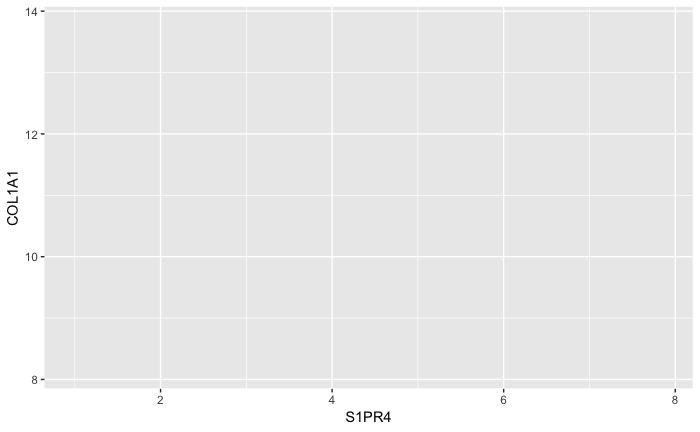

```r
g
```

Well that looks like the plot we want to make, but there’s nothing on it. That’s because we need to add something called a layer. So we have the ggplot function, with the aes inside that tells the program what the x and y axes should be, and then there’s the “geom” component, and that is how we will indicate what we want the data to look like on the plot. And we’ve given you a cheat sheet for how to choose various types of “geoms”. The options are ones you’re familiar with, like geom_point will give you a scatter plot, and geom_boxplot will give you a box plot. Let’s add a geom_point layer to our graph so we can see the data.

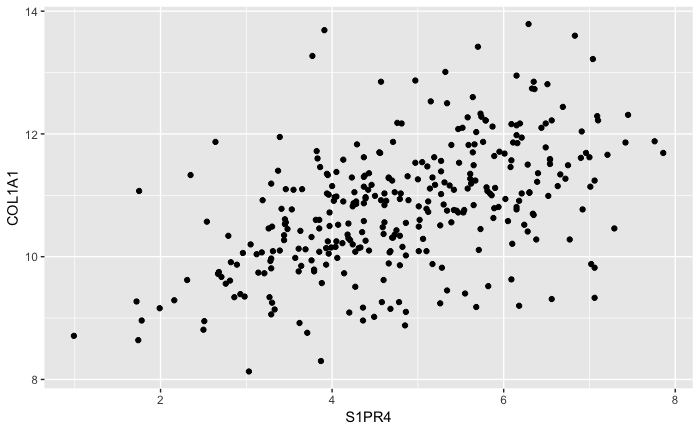

```r
### We start again with the command, the data frame, and the two variables we want to plot.
g = ggplot(exp_data, aes(S1PR4,COL1A1))
### Next, we add the geom layer, we just rename our object g as the first line + a geom layer
g = g + geom_point()
### Finally, we look at the plot!
g
```

Now we can tell that there’s a correlation between the the two genes. But what if we want to fit a line to this data, just to visualize the trend? We can add a layer called geom_smooth, just like geom_point, and looking at the plot, we can try to fit a linear model, so we tell geom_smooth that it should use method = lm, for linear model.

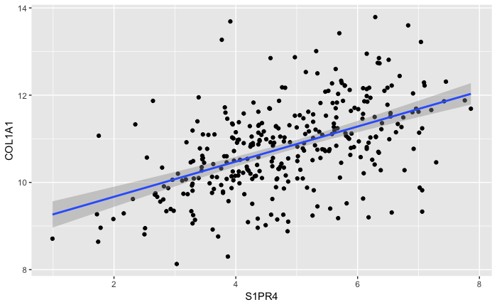

```r
### We start again with the command, the data frame, and the two variables we want to plot.
g = ggplot(exp_data, aes(S1PR4,COL1A1))
### Next, we add the geom layer, we just rename our object g as the first line + a geom layer
g = g + geom_point() + geom_smooth(method = lm)
### Finally, we look at the plot!
g
```

Let’s try it again, but this time with different variables. Let’s look at the relationship between race and COL1A1 expression. Let’s just plug it in to the last command we used.

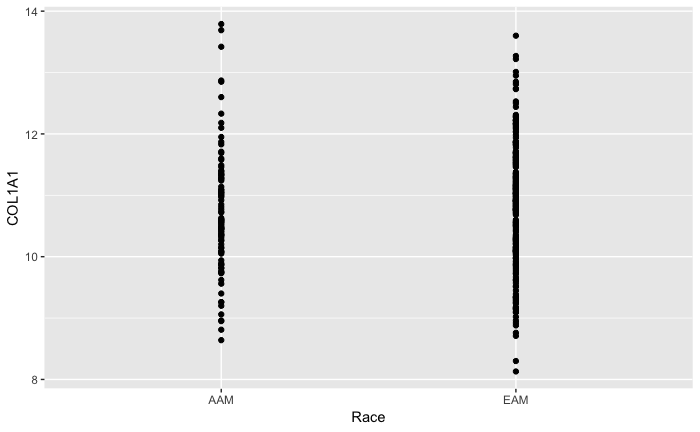

```r
### We start again with the command, the data frame, and the two variables we want to plot.
g = ggplot(exp_data, aes(Race,COL1A1))
### Next, we add the geom layer, we just rename our object g as the first line + a geom layer
g = g + geom_point()
### Finally, we look at the plot!
g
```

Well that’s not quite what we want… Clearly the wrong geom. With one discrete variable and one continuous variable, we should plot this as a box_plot.

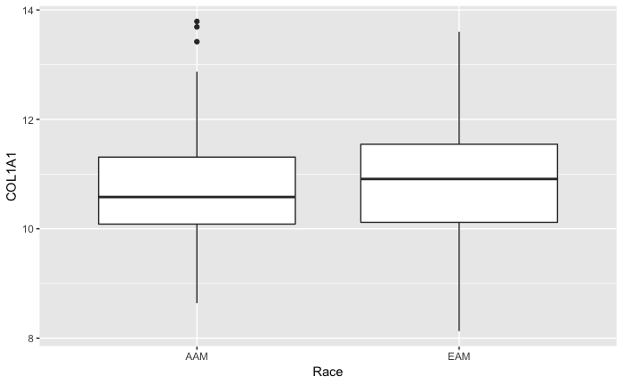

```r
### We start again with the command, the data frame, and the two variables we want to plot.
g = ggplot(exp_data, aes(Race,COL1A1))
### Next, we add the geom layer, we just rename our object g as the first line + a geom layer
g = g + geom_boxplot()
### Finally, we look at the plot!
g
```

The boxplot is nice, but what if we want to know more about the specific data points, and also have our boxplot? Just add another layer to the plot.

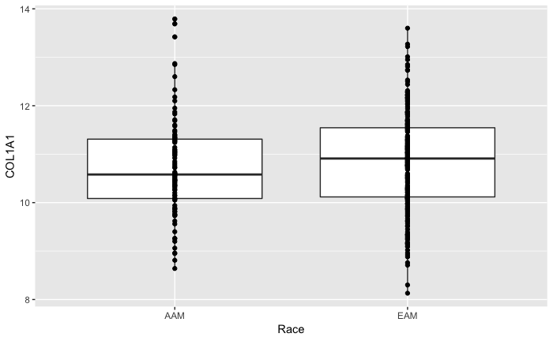

```r
### We start again with the command, the data frame, and the two variables we want to plot.
g = ggplot(exp_data, aes(Race,COL1A1))
### Next, we add the geom layer, we just rename our object g as the first line + a geom layer
g = g + geom_boxplot() + geom_point()
### Finally, we look at the plot!
g
```

Finally, let’s clean up the labels, so everyone who looks at it knows what it represents!

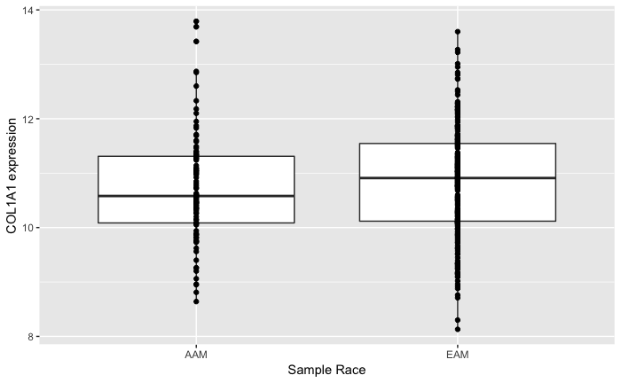

```r
### We start again with the command, the data frame, and the two variables we want to plot.
g = ggplot(exp_data, aes(Race,COL1A1))
### Next, we add the geom layer, we just rename our object g as the first line + a geom layer
g = g + geom_boxplot() + geom_point()
### Next, let's change the axes
g = g + xlab("Sample Race") + ylab("COL1A1 expression")
### Finally, we look at the plot!
g
```

These are just some basic plots we can make using ggplots. and if you want to do more with your ggplot, the easiest way to figure out how to do it is to google what you want to do. For example, just type in “color the points by a certain column in ggplot2”, or “changing the x and y axis titles in ggplot2”. One of the top three hits will likely be an in depth tutorial that can help you build whatever plot you want.